# Chi-Squared Test & Fisher’s Exact Test

[Sushank Pokhrel (Homepage)](https://sushank.com.np)

This document provides an in-depth explanation of:

1. How to perform a **Chi-Squared Test** to evaluate the association between categorical variables.
2. When to use **Fisher’s Exact Test** as an alternative for small sample sizes.
3. Visualization techniques to interpret the results.

We will demonstrate this analysis using a cancer dataset that contains categorical variables like **Cancer Status** and **Smoking Category**.

### 1. Data Import and Overview

First, we import the cancer dataset from an Excel file using the `readxl` package and examine its structure.

```r
# Load the readxl package for reading Excel files
library(readxl)
# Import the cancer data from an Excel file
cancer_data <- readxl::read_excel(
  "D:/Drive/r_training/Datasets/cancer_dummy_data.xlsx",
  sheet = "Sheet1"
)
```

### 2. Exploring the Dataset

```r
# Display the structure of the dataset to understand variable types
str(cancer_data)
```

```
## tibble [1,000 × 3] (S3: tbl_df/tbl/data.frame)
##  $ Respondents     : num [1:1000] 1 2 3 4 5 6 7 8 9 10 ...
##  $ Cancer_status   : chr [1:1000] "No Cancer" "No Cancer" "No Cancer" "No Cancer" ...
##  $ Smoking_Category: chr [1:1000] "Passive Smoker" "Smoker" "Non-Smoker" "Passive Smoker" ...
```

```r
# View the first few rows of the dataset
head(cancer_data)
```

```
## # A tibble: 6 × 3
##   Respondents Cancer_status Smoking_Category
##         <dbl> <chr>         <chr>
## 1           1 No Cancer     Passive Smoker
## 2           2 No Cancer     Smoker
## 3           3 No Cancer     Non-Smoker
## 4           4 No Cancer     Passive Smoker
## 5           5 No Cancer     Passive Smoker
## 6           6 Cancer        Smoker
```

- `str(cancer_data)`: Shows the data structure, including column names and data types.
- `head(cancer_data)`: Displays the first few rows to understand the dataset.

### 3. Chi-Squared Test

The Chi-Squared Test determines if there is a significant association between two categorical variables. Here, we evaluate the relationship between Cancer Status and Smoking Category.

#### Creating a Contingency Table

A contingency table summarizes the frequency of occurrences for combinations of two categorical variables.

```r
# Create a contingency table for Cancer Status and Smoking Category
cancer_table <- table(cancer_data$Cancer_status, cancer_data$Smoking_Category)


# Print the contingency table
print(cancer_table)
```

```
##
##             Non-Smoker Passive Smoker Smoker
##   Cancer           153            178    181
##   No Cancer        165            161    162
```

- `table()`: Generates a cross-tabulation of the two categorical variables.

This table serves as input for the Chi-Squared Test.

#### Performing the Chi-Squared Test (Using rstatix)

The `chisq_test` function from the `rstatix` package simplifies the process of performing the Chi-Squared Test.

```r
# Load the rstatix package
library(rstatix)
# Perform the Chi-Squared Test
chisq_result <- chisq_test(cancer_table)

# Display the test result
print(chisq_result)
```

```
## # A tibble: 1 × 6
##       n statistic     p    df method          p.signif
## * <int>     <dbl> <dbl> <int> <chr>           <chr>
## 1  1000      1.78  0.41     2 Chi-square test ns
```

#### Alternative Method: Direct Input without Contingency Table

Instead of creating a contingency table, you can directly input the variables:

```r
# Perform Chi-Squared Test with direct input
chisq_test(
  x = cancer_data$Cancer_status,
  y = cancer_data$Smoking_Category
)
```

```
## # A tibble: 1 × 6
##       n statistic     p    df method          p.signif
## * <int>     <dbl> <dbl> <int> <chr>           <chr>
## 1  1000      1.78  0.41     2 Chi-square test ns
```

- x: First categorical variable (e.g., Cancer Status).
- y: Second categorical variable (e.g., Smoking Category).

### 4. Visualizing the Chi-Squared Test Results

#### To visualize the data, we first convert the contingency table into a data frame.

```r
# Convert the contingency table to a data frame
cancer_df <- as.data.frame(cancer_table)

# Display the data frame
print(cancer_df)
```

```
##        Var1           Var2 Freq
## 1    Cancer     Non-Smoker  153
## 2 No Cancer     Non-Smoker  165
## 3    Cancer Passive Smoker  178
## 4 No Cancer Passive Smoker  161
## 5    Cancer         Smoker  181
## 6 No Cancer         Smoker  162
```

#### Creating a Bar Plot

The bar plot helps visualize the frequency distribution across categories.

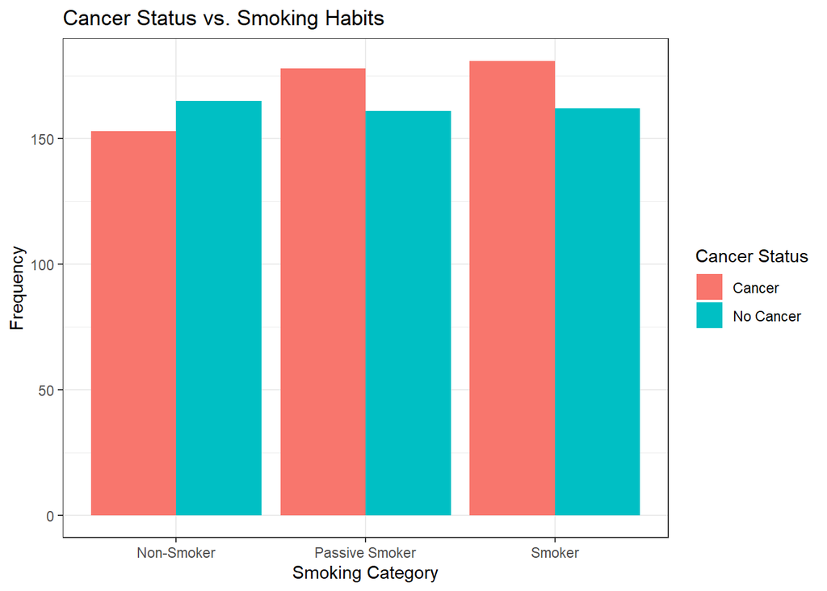

```r
# Load ggplot2 for visualization
library(ggplot2)
# Create a bar plot for Cancer Status vs Smoking Habits
ggplot(
  data = cancer_df,
  aes(
    x = Var2,
    y = Freq,
    fill = Var1
  )
) +
  geom_bar(stat = "identity", position = "dodge") +
  theme_bw() +
  labs(
    title = "Cancer Status vs. Smoking Habits",
    x = "Smoking Category",
    y = "Frequency",
    fill = "Cancer Status"
  )
```

- `geom_bar()`: Creates the bar plot.
- `aes()`: Maps variables to the x-axis (Var2), y-axis (Freq), and fill color (Var1).
- `theme_bw()`: Applies a clean theme to the plot.

### 5. Fisher’s Exact Test

When the expected frequencies in the contingency table are too low (typically <5), the Chi-Squared Test is not reliable. Instead, we use Fisher’s Exact Test.

```r
# Perform Fisher's Exact Test
fisher_result <- fisher.test(cancer_table)

# Display the test result
print(fisher_result)
```

```
##
##  Fisher's Exact Test for Count Data
##
## data:  cancer_table
## p-value = 0.4107
## alternative hypothesis: two.sided
```

Fisher’s Exact Test calculates the exact probability of the observed table under the null hypothesis. Use it for small sample sizes to avoid unreliable results from the Chi-Squared Test.

### 6. Chi-Squared Test with Alternative Data

An alternative dataset (Sheet2) contains aggregated values for analysis. We import this dataset and restructure it for the test.

#### Importing and Exploring the Alternative Dataset

```r
# Import the alternative cancer dataset
cancer_data_2 <- readxl::read_excel(
  "D:/Drive/r_training/Datasets/cancer_dummy_data.xlsx",
  sheet = "Sheet2"
)

# Display the first few rows and structure of the dataset
head(cancer_data_2)
```

```
## # A tibble: 6 × 4
##      SN Cancer_diagnose Smoking_habit  Number
##   <dbl> <chr>           <chr>           <dbl>
## 1     1 Cancer          Non-Smoker        153
## 2     2 No Cancer       Non-Smoker        165
## 3     3 Cancer          Passive Smoker    178
## 4     4 No Cancer       Passive Smoker    161
## 5     5 Cancer          Smoker            181
## 6     6 No Cancer       Smoker            162
```

```r
str(cancer_data_2)
```

```
## tibble [6 × 4] (S3: tbl_df/tbl/data.frame)
##  $ SN             : num [1:6] 1 2 3 4 5 6
##  $ Cancer_diagnose: chr [1:6] "Cancer" "No Cancer" "Cancer" "No Cancer" ...
##  $ Smoking_habit  : chr [1:6] "Non-Smoker" "Non-Smoker" "Passive Smoker" "Passive Smoker" ...
##  $ Number         : num [1:6] 153 165 178 161 181 162
```

#### Pivoting the Data

To create a contingency table from the aggregated data, we group and pivot it using dplyr and tidyr.

```r
# Load required packages
library(dplyr)
library(tidyr)

# Group and pivot the data
pivoted_data <- cancer_data_2 %>%
  group_by(Cancer_diagnose, Smoking_habit) %>%
  summarise(Number = sum(Number)) %>%
  pivot_wider(
    names_from = Smoking_habit,
    values_from = Number,
    values_fill = list(Number = 0)
  )
# Display the pivoted data
print(pivoted_data)
```

```
## # A tibble: 2 × 4
## # Groups:   Cancer_diagnose [2]
##   Cancer_diagnose `Non-Smoker` `Passive Smoker` Smoker
##   <chr>                  <dbl>            <dbl>  <dbl>
## 1 Cancer                   153              178    181
## 2 No Cancer                165              161    162
```

- `group_by()`: Groups the data by Cancer Diagnose and Smoking Habit.
- `summarise()`: Aggregates the data by summing the Number column.
- `pivot_wider()`: Reshapes the data into a wide format for the Chi-Squared Test.

#### Performing the Chi-Squared Test on Pivoted Data

```r
# Perform Chi-Squared Test on the pivoted data
chisq_result_2 <- chisq.test(as.matrix(pivoted_data[, -1]))

# Display the test result
print(chisq_result_2)
```

```
##
##  Pearson's Chi-squared test
##
## data:  as.matrix(pivoted_data[, -1])
## X-squared = 1.7828, df = 2, p-value = 0.4101
```

- `as.matrix()`: Converts the pivoted data (excluding the first column) into a matrix for analysis.

The test evaluates the relationship between smoking habits and cancer diagnoses in the aggregated dataset.